# dog_app

## Convolutional Neural Networks

## Project: Write an Algorithm for a Dog Identification App

### Why We're Here

In this notebook, you will make the first steps towards developing an algorithm that could be used as part of a mobile or web app. At the end of this project, your code will accept any user-supplied image as input. If a dog is detected in the image, it will provide an estimate of the dog's breed. If a human is detected, it will provide an estimate of the dog breed that is most resembling.

In this real-world setting, you will need to piece together a series of models to perform different tasks; for instance, the algorithm that detects humans in an image will be different from the CNN that infers dog breed. There are many points of possible failure, and no perfect algorithm exists. Your imperfect solution will nonetheless create a fun user experience!

### The Road Ahead

- Step 0: Import Datasets
- Step 1: Detect Humans
- Step 2: Detect Dogs
- Step 3: Create a CNN to Classify Dog Breeds (from Scratch)
- Step 4: Create a CNN to Classify Dog Breeds (using Transfer Learning)
- Step 5: Write your Algorithm
- Step 6: Test Your Algorithm

## Step 0: Import Datasets

### Import Dog Dataset

```python
from sklearn.datasets import load_files
from keras.utils import np_utils
import numpy as np
from glob import glob

# function to load train, test, and validation datasets
def load_dataset(path):
    data = load_files(path)
    dog_files = np.array(data['filenames'])
    dog_targets = np_utils.to_categorical(np.array(data['target']), 133)
    return dog_files, dog_targets

# load train, test, and validation datasets
train_files, train_targets = load_dataset('data/dogImages/train')
valid_files, valid_targets = load_dataset('data/dogImages/valid')
test_files, test_targets = load_dataset('data/dogImages/test')

# load list of dog names
dog_names = [item[20:-1] for item in sorted(glob("data/dogImages/train/*/"))]

# print statistics about the dataset
print('There are {} total dog categories.'.format(len(dog_names)))
print('There are {} total dog images.\n'.format(len(np.hstack([train_files, valid_files, test_files]))))
print('There are {} training dog images.'.format(len(train_files)))
print('There are {} validation dog images.'.format(len(valid_files)))
print('There are {} test dog images.'.format(len(test_files)))
```

```
There are 133 total dog categories.
There are 8351 total dog images.

There are 6680 training dog images.
There are 835 validation dog images.
There are 836 test dog images.
```

### Import Human Dataset

```python
import random
random.seed(8675309)


human_files = np.array(glob("data/lfw/*/*"))
random.shuffle(human_files)
print('There are {} total human images.'.format(len(human_files)))
```

```
There are 13233 total human images.
```

## Step 1: Detect Humans

I use OpenCV's implementation of Haar feature-based cascade classifiers to detect human faces in images.

```python
import cv2
import matplotlib.pyplot as plt
%matplotlib inline

# extract pre-trained face detector
face_cascade = cv2.CascadeClassifier('haarcascades/haarcascade_frontalface_alt.xml')

# return "True" if at least a face is detected in the image
def human_detector(img_path):
    img = cv2.imread(img_path)
    gray = cv2.cvtColor(img, cv2.COLOR_BGR2GRAY)
    faces = face_cascade.detectMultiScale(gray)
    wrong_faces = 0
    for (x,y,w,h) in faces:
        cv2.rectangle(img,(x,y),(x+w,y+h),(255,0,0),2)
        # check if face is smaller than 14% of the image
        # (most wrong detections are caused by this problem)
        img_w, img_h = img.shape[0], img.shape[1]
        if (w * 100 / img_w) < 14. and (h * 100 / img_h) < 14.:
            wrong_faces += 1
    prediction = (len(faces) - wrong_faces) > 0
    return prediction
```

```python
# Test the function
humans_in_human_images = 0.
humans_in_dog_images = 0.


for human_file, dog_file in zip(human_files[:100], train_files[:100]):
    if human_detector(human_file):
        humans_in_human_images += 1
    if human_detector(dog_file):
        humans_in_dog_images += 1
print("In 100 human images, {}% are detected as human images".format(humans_in_human_images))
print("In 100 dog images, {}% are detected as human images".format(humans_in_dog_images))
```

```
In 100 human images, 100.0% are detected as human images
In 100 dog images, 5.0% are detected as human images
```

I might improve this results, but mistakes appear only on dog images.

## Step 2: Detect Dogs

I use a pre-trained ResNet-50 model along with weights that have been trained on ImageNet dataset.  
Given an image, this pre-trained ResNet-50 model returns a prediction (derived from the available categories in ImageNet) for the object that is contained in the image.

```python
from keras.applications.resnet50 import ResNet50
from keras.preprocessing import image
from tqdm import tqdm

# define ResNet50 model
ResNet50_model = ResNet50(weights='imagenet')
```

### Pre-process the Data

```python
# loads RGB image and convert it to 4D tensor with shape (1, 224, 224, 3)
def path_to_tensor(img_path):
    img = image.load_img(img_path, target_size=(224, 224))
    x = image.img_to_array(img)
    return np.expand_dims(x, axis=0)

# apply the above function a collection of images path
def paths_to_tensor(img_paths):
    list_of_tensors = [path_to_tensor(img_path) for img_path in tqdm(img_paths)]
    return np.vstack(list_of_tensors)
```

### Write a Dog Detector

The model will return the index of the 1000 labels in the ImageNet dataset. The categories corresponding to dogs are between 151 and 268 inclusive.

```python
from keras.applications.resnet50 import preprocess_input, decode_predictions

# returns "True" if a dog is detected in the image stored at img_path
def dog_detector(img_path):
    img = preprocess_input(path_to_tensor(img_path))
    prediction = np.argmax(ResNet50_model.predict(img))
    return 151 <= prediction <= 268
```

```python
# Test the performance of the dog_detector function
humans_in_human_images = 0.
humans_in_dog_images = 0.

for human_file, dog_file in zip(human_files[:100], train_files[:100]):
    if dog_detector(human_file):
        humans_in_human_images += 1
    if dog_detector(dog_file):
        humans_in_dog_images += 1

print("In 100 human images, {}% are detected as dog images".format(humans_in_human_images))
print("In 100 dog images, {}% are detected as dog images".format(humans_in_dog_images))
```

```
In 100 human images, 1.0% are detected as dog images
In 100 dog images, 100.0% are detected as dog images
```

## Step 3: Create a CNN to Classify Dog Breeds (from Scratch)

The task of assigning breed to dogs from images is considered exceptionally challenging. To see why, consider that *even a human* would have great difficulty in distinguishing between a Brittany and a Welsh Springer Spaniel.

[output not shown]

It is not difficult to find other dog breed pairs with minimal inter-class variation (for instance, Curly-Coated Retrievers and American Water Spaniels).

[output not shown]

Likewise, recall that labradors come in yellow, chocolate, and black. Your vision-based algorithm will have to conquer this high intra-class variation to determine how to classify all of these different shades as the same breed.

[output not shown]

A random chance presents an exceptionally low bar: setting aside the fact that the classes are slightly imabalanced, a random guess will provide a correct answer roughly 1 in 133 times, which corresponds to an accuracy of less than 1%.

### Pre-process the Data

```python
from PIL import ImageFile
ImageFile.LOAD_TRUNCATED_IMAGES = True

# pre-process the data for Keras by converting every value in range 0 - 1
train_tensors = paths_to_tensor(train_files).astype('float32')/255
valid_tensors = paths_to_tensor(valid_files).astype('float32')/255
test_tensors = paths_to_tensor(test_files).astype('float32')/255
```

### Model Architecture

I have alternated Conv2D layers with Pooling layers in order to gradually convert the matrix into a long vector. The layers are alternated like in the VGG16/VGG19 model but with less filters and layers in order to have less parameters to train and make the train process faster.

```python
from keras.layers import Conv2D, MaxPooling2D, GlobalAveragePooling2D
from keras.layers import Dropout, Flatten, Dense
from keras.models import Sequential

model = Sequential()
model.add(Conv2D(32, 3, activation="relu", input_shape=(224, 224, 3)))
model.add(MaxPooling2D(2))
model.add(Conv2D(64, 3, activation="relu"))
model.add(MaxPooling2D(2))
model.add(Conv2D(128, 3, activation="relu"))
model.add(MaxPooling2D(2))
model.add(Conv2D(128, 3, activation="relu"))
model.add(MaxPooling2D(2))
model.add(Conv2D(128, 3, activation="relu"))
model.add(GlobalAveragePooling2D())
model.add(Dense(133, activation='softmax'))
model.summary()
```

```
_________________________________________________________________
Layer (type)                 Output Shape              Param #
=================================================================
conv2d_1 (Conv2D)            (None, 222, 222, 32)      896
_________________________________________________________________
max_pooling2d_2 (MaxPooling2 (None, 111, 111, 32)      0
_________________________________________________________________
conv2d_2 (Conv2D)            (None, 109, 109, 64)      18496
_________________________________________________________________
max_pooling2d_3 (MaxPooling2 (None, 54, 54, 64)        0
_________________________________________________________________
conv2d_3 (Conv2D)            (None, 52, 52, 128)       73856
_________________________________________________________________
max_pooling2d_4 (MaxPooling2 (None, 26, 26, 128)       0
_________________________________________________________________
conv2d_4 (Conv2D)            (None, 24, 24, 128)       147584
_________________________________________________________________
max_pooling2d_5 (MaxPooling2 (None, 12, 12, 128)       0
_________________________________________________________________
conv2d_5 (Conv2D)            (None, 10, 10, 128)       147584
_________________________________________________________________
global_average_pooling2d_1 ( (None, 128)               0
_________________________________________________________________
dense_1 (Dense)              (None, 133)               17157
=================================================================
Total params: 405,573
Trainable params: 405,573
Non-trainable params: 0
_________________________________________________________________
```

### Compile and Train the Model

```python
from keras.callbacks import ModelCheckpoint


model.compile(optimizer='rmsprop', loss='categorical_crossentropy', metrics=['accuracy'])


checkpointer = ModelCheckpoint(filepath='saved_models/weights.best.from_scratch.hdf5',
                               verbose=1, save_best_only=True)

model.fit(train_tensors, train_targets,
          validation_data=(valid_tensors, valid_targets),
          epochs=5, batch_size=20, callbacks=[checkpointer], verbose=1)
```

```
Train on 6680 samples, validate on 835 samples

Epoch 00001: val_loss improved from inf to 4.82097, saving model to saved_models/weights.best.from_scratch.hdf5

Epoch 00002: val_loss improved from 4.82097 to 4.67051, saving model to saved_models/weights.best.from_scratch.hdf5

Epoch 00003: val_loss improved from 4.67051 to 4.58012, saving model to saved_models/weights.best.from_scratch.hdf5

Epoch 00004: val_loss improved from 4.58012 to 4.34785, saving model to saved_models/weights.best.from_scratch.hdf5

Epoch 00005: val_loss did not improve from 4.34785
```

```
<keras.callbacks.History at 0x7f5fc8507a20>
```

### Load the Model with the Best Validation Loss

```python
model.load_weights('saved_models/weights.best.from_scratch.hdf5')
```

### Test the Model

```python
# get index of predicted dog breed for each image in test set
dog_breed_predictions = [np.argmax(model.predict(np.expand_dims(tensor, axis=0))) for tensor in test_tensors]

test_accuracy = 100*np.sum(np.array(dog_breed_predictions)==np.argmax(test_targets, axis=1))/len(dog_breed_predictions)
print('Test accuracy: %.4f%%' % test_accuracy)
```

```
Test accuracy: 6.4593%
```

The accuracy of the model is very low, let's improve it by using transfert learning.

## Step 4: Create a CNN to Classify Dog Breeds (using Transfer Learning)

I will now use transfer learning to create a CNN that can identify dog breed from images. I will use - [Xception](https://s3-us-west-1.amazonaws.com/udacity-aind/dog-project/DogXceptionData.npz) bottleneck features for this pourpose.

### Obtain Bottleneck Features

```python
bottleneck_features = np.load('bottleneck_features/DogXceptionData.npz')
train_Xception = bottleneck_features['train']
valid_Xception = bottleneck_features['valid']
test_Xception = bottleneck_features['test']
```

### Model Architecture

```python
Xception_model = Sequential()
Xception_model.add(GlobalAveragePooling2D(input_shape=(7, 7, 2048)))
Xception_model.add(Dense(133, activation='softmax'))
Xception_model.summary()
```

```
_________________________________________________________________
Layer (type)                 Output Shape              Param #
=================================================================
global_average_pooling2d_2 ( (None, 2048)              0
_________________________________________________________________
dense_2 (Dense)              (None, 133)               272517
=================================================================
Total params: 272,517
Trainable params: 272,517
Non-trainable params: 0
_________________________________________________________________
```

### Compile the Model

```python
Xception_model.compile(loss='categorical_hinge', optimizer='SGD', metrics=['accuracy'])
```

### Train the Model

```python
checkpointer = ModelCheckpoint(filepath='saved_models/Xception_model.weights.best.hdf5', verbose=1,
                               save_best_only=True)
Xception_model.fit(train_Xception, train_targets, epochs=3000, validation_data=(valid_Xception, valid_targets),
                   callbacks=[checkpointer], verbose=0, shuffle=True)
```

[output not shown]

[output cut: 5944 more lines]

```
Epoch 02993: val_loss did not improve from 0.30218

Epoch 02994: val_loss did not improve from 0.30218

Epoch 02995: val_loss did not improve from 0.30218

Epoch 02996: val_loss did not improve from 0.30218

Epoch 02997: val_loss did not improve from 0.30218

Epoch 02998: val_loss did not improve from 0.30218

Epoch 02999: val_loss did not improve from 0.30218

Epoch 03000: val_loss did not improve from 0.30218
```

```
<keras.callbacks.History at 0x7f5fc369a9b0>
```

### Load the Model with the Best Validation Loss

```python
Xception_model.load_weights('saved_models/Xception_model.weights.best.hdf5')
```

### Test the Model

```python
# get index of predicted dog breed for each image in test set
Xception_predictions = [np.argmax(Xception_model.predict(np.expand_dims(feature, axis=0))) for feature in test_Xception]

test_accuracy = 100*np.sum(np.array(Xception_predictions)==np.argmax(test_targets, axis=1))/len(Xception_predictions)
print('Test accuracy: %.4f%%' % test_accuracy)
```

```
Test accuracy: 85.7656%
```

### Predict Dog Breed with the Model

```python
from extract_bottleneck_features import *

# return dog breed from image path
def Xception_predict_breed(img_path):
    bottleneck_feature = extract_Xception(path_to_tensor(img_path))
    predicted_vector = Xception_model.predict(bottleneck_feature)
    return dog_names[np.argmax(predicted_vector)].split(".")[1]
```

## Step 5: Write your Algorithm

Write an algorithm that accepts a file path to an image and first determines whether the image contains a human, dog, or neither. Then,

- if a **dog** is detected in the image, return the predicted breed.
- if a **human** is detected in the image, return the resembling dog breed.
- if **neither** is detected in the image, provide output that indicates an error.

[figure not shown]

```python
import os


#check if the provided path exist and has a supported extension
def check_file_path(img_path):
    if not os.path.isfile(img_path):
        return False, "The provided path doesn't exist!"
    extensions = [".jpg", ".jpeg", ".png", ".bmp"]
    for ext in extensions:
        if img_path.endswith(ext):
            return True, ""
    return False, 'The file is not supported, only "jpg", "jpeg", "png" and "bmp" are accepted.'


def show_image(image_path):
    img = cv2.imread(image_path)
    img = cv2.cvtColor(img, cv2.COLOR_BGR2RGB)
    plt.imshow(img)
    plt.show()


def dog_breed_prediction(image_path):
    path_is_ok, outputstring = check_file_path(image_path)
    if not path_is_ok:
        print(outputstring, "\n")
        return None
    is_human = human_detector(image_path)
    is_dog = dog_detector(image_path)
    if is_dog:
        print("Hello, dog!")
        breed = Xception_predict_breed(image_path)
        show_image(image_path)
        print("This is a {}!".format(breed))
    elif is_human:
        print("Hello, human!")
        breed = Xception_predict_breed(image_path)
        show_image(image_path)
        print("You look like a ...\n{}!".format(breed))
    else:
        print("Error, not able to detect humans or dogs in the provided picture!")
        show_image(image_path)
```

## Step 6: Test Your Algorithm

Test your algorithm at least six images on your computer. Feel free to use any images you like.

```
Error, not able to detect humans or dogs in the provided picture!
```

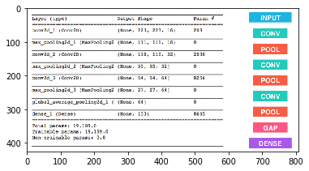

```
It was a sample_cnn.png


Hello, dog!
```

[figure not shown]

```
This is a Chesapeake_bay_retriever!
It was a Labrador_retriever_06455.jpg


Hello, dog!
```

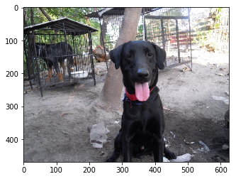

```
This is a Labrador_retriever!
It was a Labrador_retriever_06449.jpg


Hello, dog!
```

[figure not shown]

```
This is a Curly-coated_retriever!
It was a American_water_spaniel_00648.jpg


Hello, human!
```

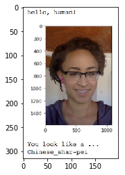

```
You look like a ...
American_staffordshire_terrier!
It was a sample_human_output.png


Hello, dog!
```

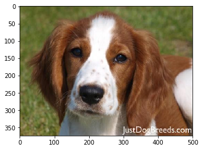

```
This is a Welsh_springer_spaniel!
It was a Welsh_springer_spaniel_08203.jpg


Hello, dog!
```

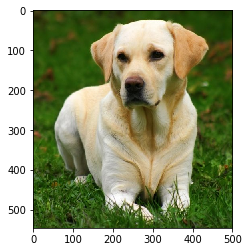

```
This is a Labrador_retriever!
It was a Labrador_retriever_06457.jpg


Hello, dog!
```

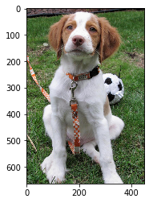

```
This is a Brittany!
It was a Brittany_02625.jpg


Hello, dog!
```

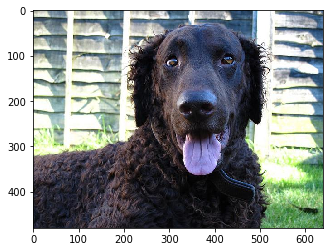

```
This is a Curly-coated_retriever!
It was a Curly-coated_retriever_03896.jpg
```

```python
for img in os.listdir("images"):
    dog_breed_prediction(os.path.join("images", img))
    print("It was a {}\n\n".format(img))
```